# Data Visualization Project

# Graphs

## Initial exploration of the dataset

### **Chart Type:** Barplot with one numeric variable

We have defined a function for this type of plot and called it for each of the scenarios.

```r
initial_eda_barplots <- function(all_labels, all_values, x_name, y_name, plot_title, colour){

  data=data.frame(name = all_labels, value = all_values)

  totalIncidentsBarPlot <- ggplot(data, aes(x=name, y = value)) + geom_bar(stat = "identity", width=0.7, fill = colour) +
    xlab(x_name) +
    ylab(y_name) +
    ggtitle(plot_title)

  totalIncidentsBarPlot +
    theme(
      plot.title = element_text(hjust = 0.5),
      panel.grid.major = element_blank(),
      panel.grid.minor = element_blank(),
      panel.background = element_rect(fill = "white"),
      axis.text.x = element_text(angle = 90, vjust = 0.5)
  )
}
```

**Variable: Total number of incidents that occured**

We want to see the distribution of the total number of incidents per each state. We will use the `totalPerState` dataframe and the codes from the `stateCodes` array.

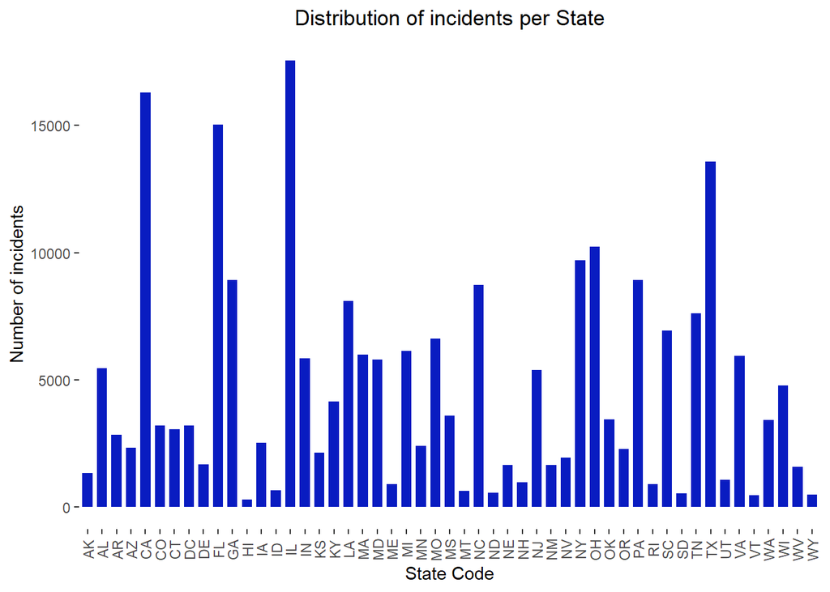

```r
r_totalPerState <- py$totalPerState
r_labels <- py$stateCodes

initial_eda_barplots(r_labels, r_totalPerState, "State Code", "Number of incidents", "Distribution of incidents per State", "#091CC1")
```

**Variable: Total number of cases that resulted in killings**

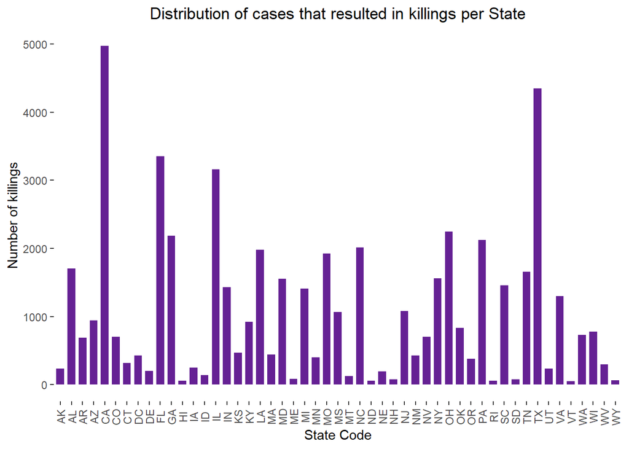

```r
r_totalKillingsPerState <- py$totalKillingsPerState

initial_eda_barplots(r_labels, r_totalKillingsPerState, "State Code", "Number of killings", "Distribution of cases that resulted in killings per State", "#652194")
```

**Variable: Total number of cases that resulted in injuries**

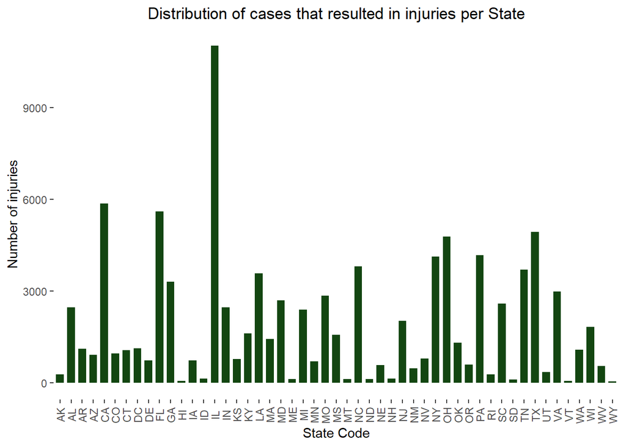

```r
r_totalInjuriesPerState <- py$totalInjuriesPerState

initial_eda_barplots(r_labels, r_totalInjuriesPerState, "State Code", "Number of injuries", "Distribution of cases that resulted in injuries per State", "#134611")
```

Outlier values can be noticed in the last two charts as well. Given this observation, it would make sense to realize another chart - a Boxplot - that would specifically highlight this information. Even though boxplots can sometimes be missleading because of the loss of information, our purpose for this scenario is to identify those states that do not fall into the IQR (Interquantile Range), purpose which makes this type of chart appropiate.

### **Chart Type:** Boxplot with three series

**Variables: Total number of incidents, firearm deaths and injuries, respectively**

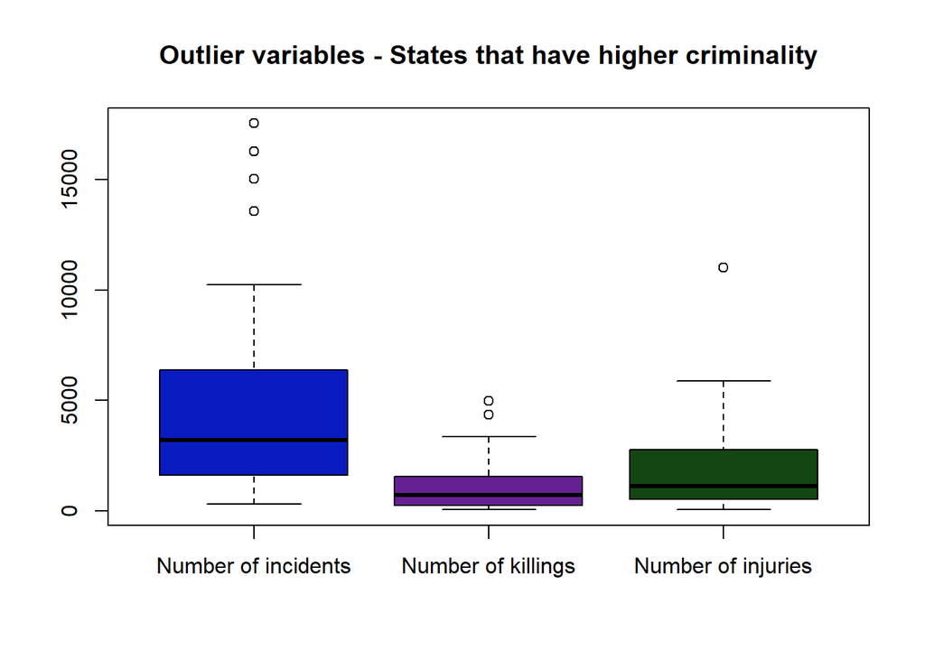

```r
r_totalPerState <- py$totalPerState
r_totalKillingsPerState <- py$totalKillingsPerState
r_totalInjuriesPerState <- py$totalInjuriesPerState

p <- boxplot(r_totalPerState, r_totalKillingsPerState, r_totalInjuriesPerState,
main = "Outlier variables - States that have higher criminality",
names = c("Number of incidents", "Number of killings", "Number of injuries"),
col = c("#091CC1","#652194", "#134611")
)
```

```r
p
```

```
## $stats
##         [,1]   [,2]   [,3]
## [1,]   289.0   47.0   47.0
## [2,]  1610.0  234.0  515.0
## [3,]  3201.0  704.0 1120.0
## [4,]  6383.5 1555.5 2770.5
## [5,] 10244.0 3354.0 5870.0
## attr(,"class")
## Number of incidents
##           "integer"
##
## $n
## [1] 51 51 51
##
## $conf
##          [,1]     [,2]      [,3]
## [1,] 2144.891 411.6257  620.9836
## [2,] 4257.109 996.3743 1619.0164
##
## $out
## [1] 16306 15029 17556 13577  4972  4350 11023
##
## $group
## [1] 1 1 1 1 2 2 3
##
## $names
## [1] "Number of incidents" "Number of killings"  "Number of injuries"
```

### **Chart Type:** Doughnut Plot

The first type of analysis targets the age categories. For this purpose, the data was visualized in separate doughnut charts as seen below.

Calculating the percentage of Child, Teenager and Adult participants for each state.

```python
outlierList = np.array(["Pennsylvania", "California", "Colorado"])
totalsStates = np.zeros(shape=(len(outlierList),3), dtype = float)
categories = np.array(["CHILDREN", "TEENAGERS", "ADULTS"])

for i in range(0,len(outlierList)):
    state = outlierList[i]
    array = []

    dfHelper = fullsetDF[fullsetDF["state"]==state][categories[0]].copy(deep=True)
    totalsStates[i][0] = dfHelper.sum().item()

    dfHelper = fullsetDF[fullsetDF["state"]==state][categories[1]].copy(deep=True)
    totalsStates[i][1] = dfHelper.sum().item()

    dfHelper = fullsetDF[fullsetDF["state"]==state][categories[2]].copy(deep=True)
    totalsStates[i][2] = dfHelper.sum().item()

# Percentages per state for each group
for i in range(0, len(outlierList)):
    total = totalsStates[i][0] + totalsStates[i][1] + totalsStates[i][2]
    for j in range(0, 3):
        totalsStates[i][j] = float("{:.4f}".format(totalsStates[i][j] / total))*100
```

```r
donut_plot_labels <- function(all_labels, all_values) {

data = data.frame(name = all_labels, value = all_values)

data$ymax = cumsum(all_values)
data$ymin = c(0, head(data$ymax, n=-1))

data$labelPosition <- (data$ymax + data$ymin) / 2
data$label <- paste0(data$name, ": ", data$value, "%")

ggplot(data, aes(ymax=ymax, ymin=ymin, xmax=4, xmin=3, fill=name)) +
  geom_rect() +
  geom_text( x=2, aes(y=labelPosition, label=label, color=name), size=3) +
  scale_fill_brewer(palette = "Dark2") +
  scale_color_brewer(palette = "Dark2") +
  coord_polar(theta="y") +
  xlim(c(-1, 4))
}
```

**Variables: Percentage of each age group involved in an incident per state and across the states.**

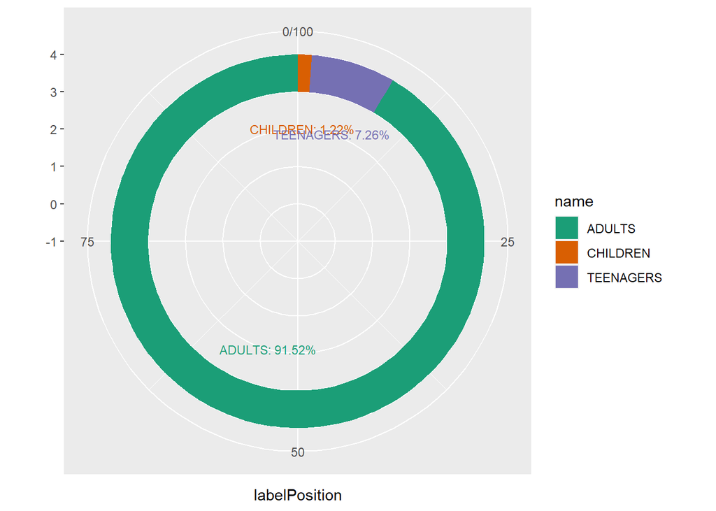

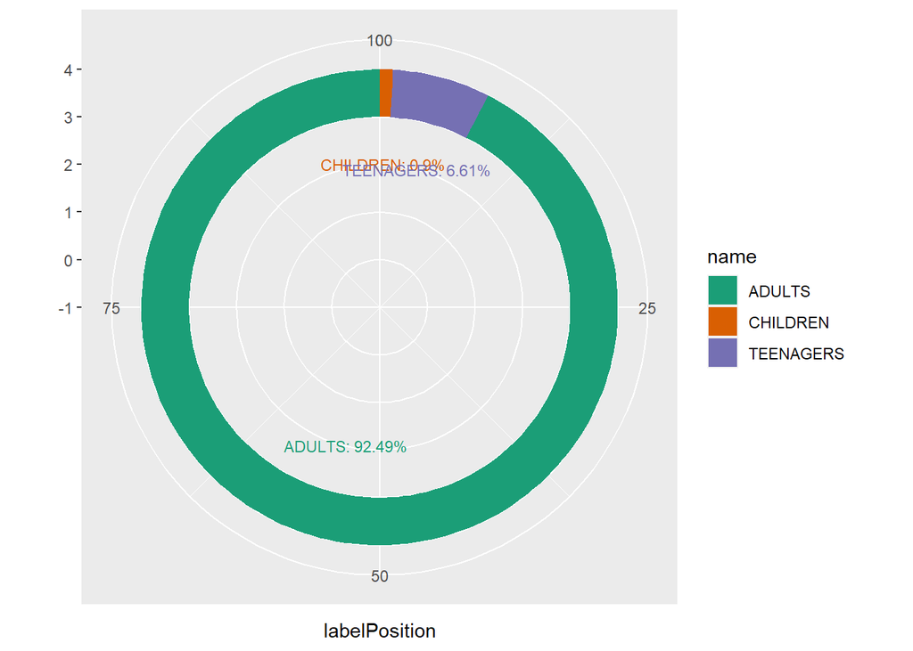

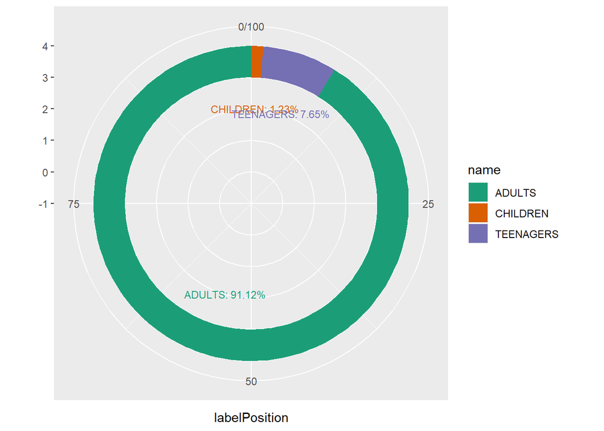

```r
r_categories <- py$categories
matrix <- py$totalsStates
for(row in 1 : nrow(matrix)){
  r_totalsStates<- matrix[row,]
  print(donut_plot_labels(r_categories, r_totalsStates))
}
```

```python
# Percentages per group for each state
for j in range(0, 3):
    total = totalsStates[0][j] + totalsStates[1][j] + totalsStates[2][j]
    for i in range(0, len(outlierList)):
        totalsStates[i][j] = float("{:.4f}".format(totalsStates[i][j] / total))*100
totalsStates = totalsStates.transpose()
```

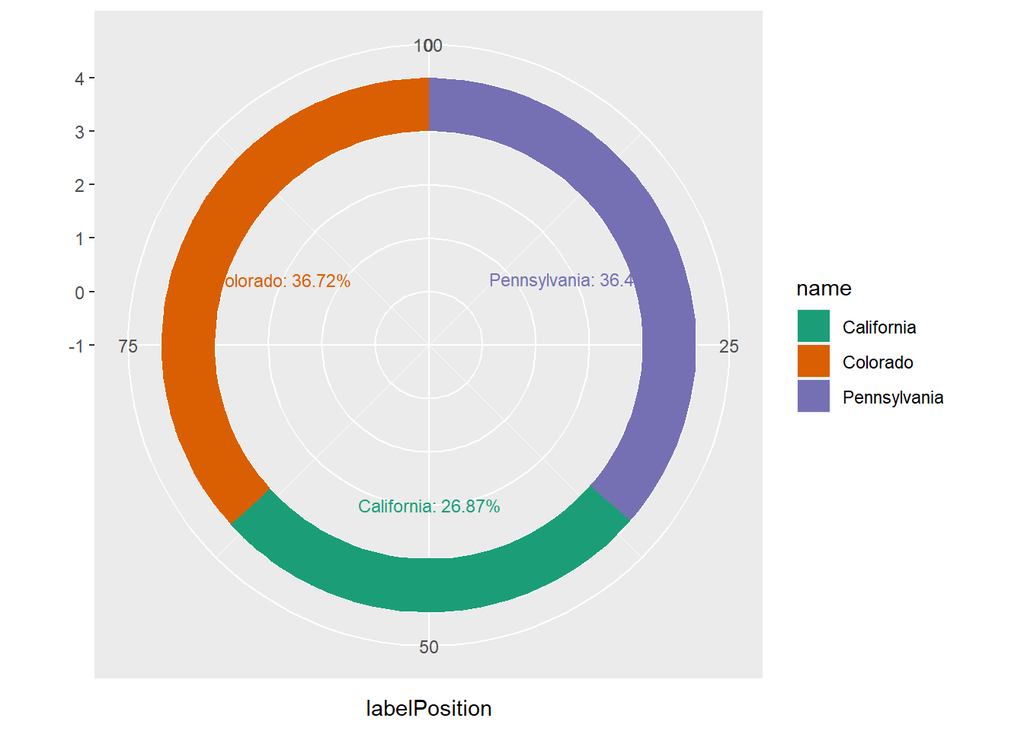

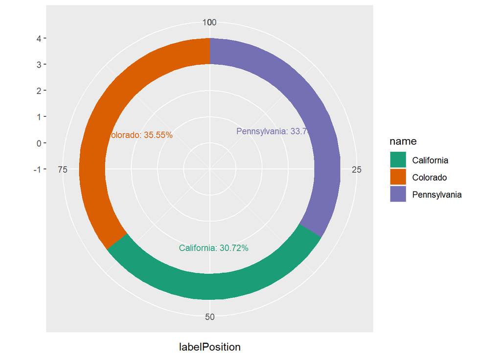

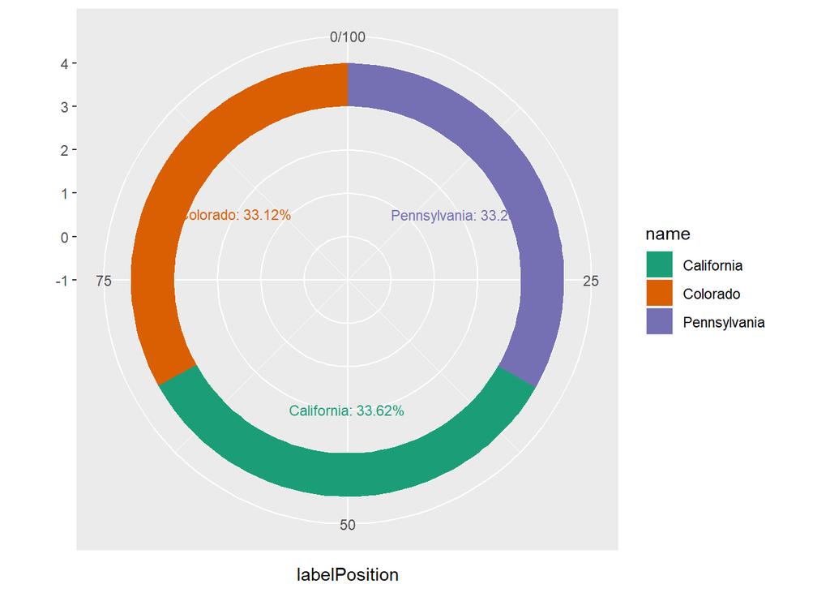

```r
r_outlierList <- py$outlierList

matrix <- py$totalsStates
for(row in 1 : nrow(matrix)){
  r_totalsStates<- matrix[row,]
  print(donut_plot_labels(r_outlierList, r_totalsStates))
}
```